# 03_PreProcessing

2025-03-31

# Goals

First, we will use the [phyloseq package](https://joey711.github.io/phyloseq/) to combine all of our data objects that we exported from the DADA2 workflow (`asv_table`, `tax_table`, and metadata) and incorporate them into a single [specialized S4 R Data object](https://adv-r.hadley.nz/s4.html), known as a phyloseq object. Then, we will remove any potential contaminants and evaluate the accuracy of our sequencing run. Finally, we will write our our single `raw_preprocessed_physeq` phyloseq data object.

## Specific Steps:

1. Load in data that we’ve generated in `analysis/02_AssignASVs.Rmd` and fix all of the names to match each other. *The names must match for us to incorporate them into the S4 phyloseq object*:
   1. `asv_table`: ASVs (rows) x Samples (columns)
   2. `tax_table`: ASV (rows) x Taxonomy (columns)
   3. `metadata`: Samples (rows) x All our data (*e.g. pH, Temp, treatment group, etc*; columns)
2. Combine the data into a phyloseq object.
3. Remove any contaminating ASVs that are **chloroplasts**.
4. Remove ASVs that are **mitochondria**.
5. Evaluate any ASVs from the **negative controls**. Then, remove negative controls.
6. Evaluate the mock community or **positive control** to learn the accuracy of sequencing.
7. Check for **reverse complements**.
8. Check the **sequencing depth** of samples. Remove samples that obviously have too few reads.
9. Write a `raw_preprocessed_physeq` to be used in the next step of our workflow.

## Output

1. A **pre-processed S4 phyloseq object**: `raw_preprocessed_physeq.RData`.

# Set Environment

## Load Packages

```r
#install.packages("BiocManager")
#BiocManager::install("Biostrings")

# NOTE, you will need to install the following 2 packages to
# re-create the negative control plots below!
#install.packages("ggpubr")
#install.packages("rstatix")

# Load packages with pacman
# Be sure that you load dada2 & Patchwork, which we didn't do in class on March 12th
pacman::p_load(devtools, phyloseq, dada2, patchwork, Biostrings, tidyverse,
               # Note to add ggpubr & rstatix!!
               ggpubr, rstatix, install = FALSE)
```

## Timing of this script

Let’s record how long this file took to run on the class server, which we will record at the end of the script.

```r
# What time did we start running this script?
start_time <- Sys.time()
```

## 1. Load Data

### 1a. Metadata

Here, we will load in our **metadata** files, which include:

1. `data/metadata.csv`: This file contains all of our samples and also any measured variables, including station, date of collection, depth of sample, temperature, pH, salinity, etc.
2. `data/01_DADA2/track_read_counts.RData`: This file contains how many reads we maintained in our samples through the DADA2 workflow.

```r
# load in metadata
metadata_df <-
  read_csv("data/metadata.csv") %>%
  # Fix Column Name
  dplyr::rename("sample_names" = "Run") %>%
  # Add sample names also as a column
  mutate(names = sample_names)
# Inspect
head(metadata_df)
```

```
## # A tibble: 6 × 7
##   sample_names collection-day-post-ad…¹ env_broad_scale env_local_scale host_age
##   <chr>        <chr>                    <chr>           <chr>              <dbl>
## 1 SRR13675761  day-0                    antecubital-fo… burn                  39
## 2 SRR13675762  day-0                    antecubital-fo… spared                39
## 3 SRR13675763  day-14                   proximal-crus   burn                  34
## 4 SRR13675764  day-21                   rectal          rectal                61
## 5 SRR13675765  day-21                   perianal        perianal              61
## 6 SRR13675766  day-21                   ventral-upper-… burn                  61
## # ℹ abbreviated name: ¹`collection-day-post-admission`
## # ℹ 2 more variables: host_tissue_sampled <chr>, names <chr>
```

```r
dim(metadata_df)
```

```
## [1] 186   7
```

```r
# include dada2 output
load("data/01_DADA2/track_read_counts.RData")

# Take a look
glimpse(track_counts_df)
```

```
## Rows: 186
## Columns: 6
## $ sample_names <chr> "SRR13675761_R1_filtered.fastq.gz", "SRR13675762_R1_filte…
## $ denoisedF    <dbl> 30444, 46554, 38694, 37124, 29911, 525, 48697, 10840, 341…
## $ denoisedR    <dbl> 30625, 47188, 38774, 37415, 29912, 520, 49333, 10857, 344…
## $ merged       <dbl> 27722, 40964, 38394, 35837, 29711, 481, 47360, 10682, 331…
## $ nochim       <dbl> 27391, 40070, 38121, 34141, 28904, 481, 45685, 10627, 320…
## $ num_ASVs     <dbl> 689, 1046, 146, 123, 57, 35, 229, 80, 109, 131, 53, 212, …
```

```r
dim(track_counts_df)
```

```
## [1] 186   6
```

```r
# Check filenames
head(track_counts_df$sample_names)
```

```
## [1] "SRR13675761_R1_filtered.fastq.gz" "SRR13675762_R1_filtered.fastq.gz"
## [3] "SRR13675763_R1_filtered.fastq.gz" "SRR13675764_R1_filtered.fastq.gz"
## [5] "SRR13675765_R1_filtered.fastq.gz" "SRR13675766_R1_filtered.fastq.gz"
```

```r
# Fix sample names in track_reads
track_counts_df$sample_names <- sapply(strsplit(track_counts_df$sample_names, "_"), `[`, 1)

# Intuition check
head(track_counts_df$sample_names)
```

```
## [1] "SRR13675761" "SRR13675762" "SRR13675763" "SRR13675764" "SRR13675765"
## [6] "SRR13675766"
```

```r
# What's different?
setdiff(track_counts_df$sample_names, metadata_df$sample_names)
```

```
## character(0)
```

```r
# Let's do a filtering join with left_join
metadata_final_df <-
  metadata_df %>%
  left_join(., track_counts_df, by = "sample_names") %>%
  # sample names to the rownames to merge into phyloseq
  column_to_rownames(var = "sample_names")

# Check
dim(metadata_final_df)
```

```
## [1] 186  11
```

### 1b. ASV Table

Now, let’s load in the ASV count table that we created within DADA2 in `analysis/02_AssignASVs.Rmd`.

```r
asv_df <-
  read.delim(file = "data/01_DADA2/ASV_table.tsv", sep = "\t",
           # add the column names and row names
           header = TRUE, row.names = 1)
  #dplyr::select(-"CJ.V08.P")

# Inspect
asv_df[1:3, 1:3]
```

```
##          SRR13675761 SRR13675762 SRR13675763
## ASV_0001          11           0           3
## ASV_0002         141        9451         506
## ASV_0003          32          17         439
```

```r
# fix Column names
## Remove the X: denote at the beginning "^"
colnames(asv_df) <- sub(pattern = "^X", replacement = "" , colnames(asv_df))
## Replace the . with a -: "\\." since . is a special character in regex
colnames(asv_df) <- gsub(pattern = "\\.", replacement = "-", colnames(asv_df))

# Final inspection
head(colnames(asv_df))
```

```
## [1] "SRR13675761" "SRR13675762" "SRR13675763" "SRR13675764" "SRR13675765"
## [6] "SRR13675766"
```

```r
asv_df[1:3, 1:3]
```

```
##          SRR13675761 SRR13675762 SRR13675763
## ASV_0001          11           0           3
## ASV_0002         141        9451         506
## ASV_0003          32          17         439
```

### 1c. Taxonomy Table

And, let’s also load the taxonomy table that we created in `analysis/02_AssignASVs.Rmd`.

```r
tax_df <-
  read.delim("data/01_DADA2/ASV_taxonomy.tsv", sep = "\t",
           header = TRUE, row.names = 1)

# Inspect
dim(tax_df)
```

```
## [1] 6780    9
```

```r
dim(asv_df)
```

```
## [1] 6780  186
```

```r
# Add check
stopifnot(rownames(asv_df) == rownames(tax_df))
```

# 2. Handoff to phyloseq

This is where we will combine our metadata, asv count table, and taxonomy table into a single data S4 data object in R, which we will call `raw_physeq` for now.

```r
raw_physeq <-
  phyloseq(otu_table(asv_df, taxa_are_rows = TRUE),
         sample_data(metadata_final_df),
         tax_table(as.matrix(tax_df)))

# Check out
raw_physeq
```

```
## phyloseq-class experiment-level object
## otu_table()   OTU Table:         [ 6780 taxa and 186 samples ]
## sample_data() Sample Data:       [ 186 samples by 11 sample variables ]
## tax_table()   Taxonomy Table:    [ 6780 taxa by 9 taxonomic ranks ]
```

```r
# save
save(raw_physeq, file = "data/03_PreProcessing/raw_physeq.RData")
```

# Clean up the data!

## 3. Remove chloroplasts

```r
noChloros_physeq <-
  raw_physeq %>%
  subset_taxa(Order != "Chloroplast" | is.na(Order))

# How many ASVs were chloroplasts?
numChloros_ASVs <- ntaxa(raw_physeq) - ntaxa(noChloros_physeq)

numChloros_ASVs
```

```
## [1] 69
```

There were 69 ASVs that were chloroplasts.

## 4. Remove Mitochondria

```r
noChlorosMitos_physeq <-
  noChloros_physeq %>%
  subset_taxa(Family != "Mitochondria" | is.na(Family))

# How many ASVs were mitochondria?
numMitos_ASVs <- ntaxa(noChloros_physeq) - ntaxa(noChlorosMitos_physeq)

numMitos_ASVs
```

```
## [1] 18
```

There were 18 ASVs that were mitochondria in the data set.

INTERPRETATION #1: How many chloroplast and/or mitochondrial ASVs in your dataset? Does this seem reasonable? 69 chloroplasts and 18 mitochondria. This is unexpected because this data are skin samples. I would have expected chloroplast and/or mitochondrial to be in environmental samples.

# Evaluate and remove the control samples

INTERPRETATION #2: Did your dataset have any negative controls? If so, how many ASVs did you remove? Does that seem reasonable to you?

No negative control was included in the paper.

## 6. Positive Controls

INTERPRETATION #3: Did your dataset have a mock community? If so, what can you say about the accuracy of your sequencing run?

The study also didnt include positive controls.

# 7. Reverse Complements

```r
# Pull out Taxa Table
tax_table <-
  noChlorosMitos_physeq %>%
  tax_table() %>%
  data.frame()

# Grab ASV Sequences and Names
asv_names <- tax_table$ASV
asv_seqs <- tax_table$ASVseqs

# Create empty comparison matrix
asv_rev_comp <- matrix(nrow=length(asv_seqs), ncol = length(asv_seqs))

# Fix the names in the rows and columns
rownames(asv_rev_comp) <- asv_names
colnames(asv_rev_comp) <- asv_names

# Convert sequences to Biostrings
asv_dna <- DNAStringSet(asv_seqs)

# Inspect
head(asv_dna)
```

```
## DNAStringSet object of length 6:
##     width seq
## [1]   424 GGGAATTTTGGACAATGGGGGCAACCCTGATCCA...TGACGCTCATGCACGAAAGCGTGGGGAGCAAAC
## [2]   404 GGGAATATTGCACAATGGGCGGAAGCCTGATGCA...TGACGCTGAGGAGCGAAAGCGTGGGGAGCGAAC
## [3]   424 GGGAATATTGCACAATGGGCGCAAGCCTGATGCA...TGACGCTCAGGTGCGAAAGCGTGGGGAGCAAAC
## [4]   400 GGGAATATTGCGCAATGGGGGAAACCCTGACGCA...TGACACTGATGCACGAAAGCGTGGGGAGCAAAC
## [5]   424 GGGAATCTTCCGCAATGGGCGAAAGCCTGACGGA...TGACGCTGATGTGCGAAAGCGTGGGGATCAAAC
## [6]   399 GGGAATATTGCACAATGGGGGAAACCCTGATGCA...TGACGCTGAGGCACGAAAGCGTGGGGAGCAAAC
```

```r
# Construct reverse complement
asv_rev_dna <- reverseComplement(asv_dna)

# Now loop through every asv sequence to check
for(i in 1:length(asv_seqs)){ # For each asv sequence...
  match_vec <- asv_dna[i] == asv_rev_dna # Compare it to the reverse complement of every other sequence...
  asv_rev_comp[,i] <- match_vec # Write that logical vector as a new column
}

# Find how many TRUEs (matches) we have, divide by 2 because each pair occurs twice
cat("For", sum(asv_rev_comp) / 2,"ASVs, the reverse complement will need to be removed")
```

```
## For 0 ASVs, the reverse complement will need to be removed
```

INTERPRETATION #4: Do you have any reverse complements in your dataset? No reverse complement.

# 8. Sequencing Depth

```r
# The current data objec
noChlorosMitos_physeq
```

```
## phyloseq-class experiment-level object
## otu_table()   OTU Table:         [ 6693 taxa and 186 samples ]
## sample_data() Sample Data:       [ 186 samples by 11 sample variables ]
## tax_table()   Taxonomy Table:    [ 6693 taxa by 9 taxonomic ranks ]
```

```r
# What is the library size/sequencing depth for each sample?
seqSums_df <-
  noChlorosMitos_physeq %>%
  otu_table() %>%
  # Sum each sample column
  colSums() %>%
  data.frame() %>%
  rownames_to_column(var = "names") %>%
  left_join(., metadata_final_df, by = "names")

# Rename second column
colnames(seqSums_df)[2] <- "TotalSeqs"

# check
dim(seqSums_df)
```

```
## [1] 186  12
```

```r
head(seqSums_df)
```

```
##         names TotalSeqs collection-day-post-admission   env_broad_scale
## 1 SRR13675761     23855                         day-0 antecubital-fossa
## 2 SRR13675762     39720                         day-0 antecubital-fossa
## 3 SRR13675763     37971                        day-14     proximal-crus
## 4 SRR13675764     34141                        day-21            rectal
## 5 SRR13675765     28904                        day-21          perianal
## 6 SRR13675766       481                        day-21 ventral-upper-arm
##   env_local_scale host_age host_tissue_sampled denoisedF denoisedR merged
## 1            burn       39           cutaneous     30444     30625  27722
## 2          spared       39           cutaneous     46554     47188  40964
## 3            burn       34           cutaneous     38694     38774  38394
## 4          rectal       61              rectal     37124     37415  35837
## 5        perianal       61            perianal     29911     29912  29711
## 6            burn       61           cutaneous       525       520    481
##   nochim num_ASVs
## 1  27391      689
## 2  40070     1046
## 3  38121      146
## 4  34141      123
## 5  28904       57
## 6    481       35
```

```r
# Show the depth of samples
seqSums_df %>%
  dplyr::select(names, TotalSeqs) %>%
  arrange(TotalSeqs) %>%
  head()
```

```
##         names TotalSeqs
## 1 SRR13675777         1
## 2 SRR13675792         6
## 3 SRR13675766       481
## 4 SRR13675803       713
## 5 SRR13675780       758
## 6 SRR13675771      1342
```

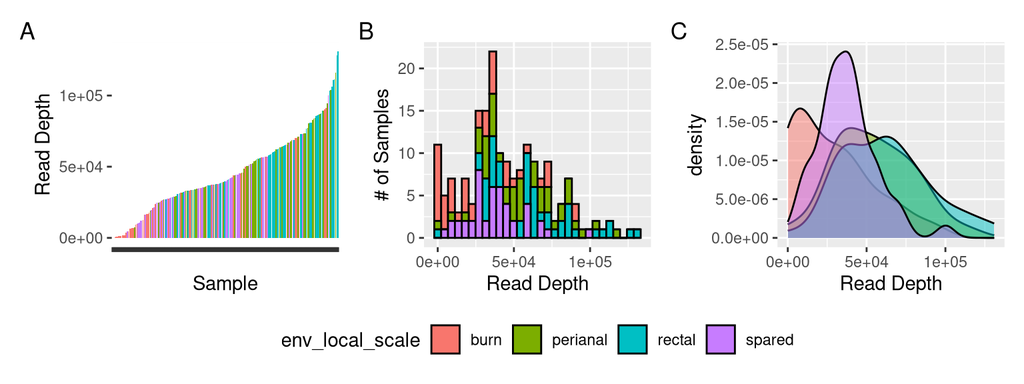

```r
# plot it as a bar plot
numSeq_bar_plot <-
  seqSums_df %>%
  ggplot(aes(x=reorder(names, TotalSeqs), y = TotalSeqs,
             fill = env_local_scale)) +
  geom_bar(stat = "identity") +
  theme(axis.text.x = element_blank()) +
  labs(y = "Read Depth", x = "Sample") +
  theme(legend.position = "none")


# histogram
numSeq_hist_plot <-
  seqSums_df %>%
  ggplot(aes(x= TotalSeqs, fill = env_local_scale)) +
  geom_histogram(color = "black") +
  labs(y = "# of Samples", x = "Read Depth") +
  theme(legend.position = "bottom")

# Density plot
numSeq_density_plot <-
  seqSums_df %>%
  ggplot(aes(TotalSeqs, fill = env_local_scale)) +
  geom_density(alpha = 0.5) +
  labs(x = "Read Depth") +
  theme(legend.position = "none")

# Put it all together
numSeq_bar_plot + numSeq_hist_plot + numSeq_density_plot +
  plot_annotation(tag_levels = "A")
```

INTERPRETATION #5: What can you conclude about your sequencing depths? What are your sample distributions? Do you have “enough” reads? Are there any samples that should be removed at this step?

Tt looks like I have enough reads in most of the samples but the sequencing depth is a little uneven across the samples. Samples at burn locations seem to have lower depth. Additionally there are some samples with read depth close to zero that should be removed.

## Remove samples with few reads

```r
# What's the min seq depth?
mindep<-min(sample_sums(noChlorosMitos_physeq))
mindep
```

```
## [1] 1
```

```r
# Remove 20210615-MA-SCB2F
raw_preprocessed_physeq <-
  noChlorosMitos_physeq %>%
  subset_samples(., names != "SRR13675777")
raw_preprocessed_physeq <-
  raw_preprocessed_physeq %>%
  subset_samples(., names != "SRR13675792")
raw_preprocessed_physeq <-
  raw_preprocessed_physeq %>%
  subset_samples(., names != "SRR13675766")
raw_preprocessed_physeq <-
  raw_preprocessed_physeq %>%
  subset_samples(., names != "SRR13675803")
raw_preprocessed_physeq <-
  raw_preprocessed_physeq %>%
  subset_samples(., names != "SRR13675780")


#What's the new min seq depth?
newmin<-min(sample_sums(raw_preprocessed_physeq))
newmin
```

```
## [1] 1342
```

```r
# Final check of the sequencing depth for now
# Here, we could remove more samples if we needed to
seqSums_df %>%
  dplyr::select(names, TotalSeqs) %>%
  arrange(TotalSeqs) %>%
  head(n = 10)
```

```
##          names TotalSeqs
## 1  SRR13675777         1
## 2  SRR13675792         6
## 3  SRR13675766       481
## 4  SRR13675803       713
## 5  SRR13675780       758
## 6  SRR13675771      1342
## 7  SRR13675824      1366
## 8  SRR13675775      1491
## 9  SRR13675815      1659
## 10 SRR13675850      1685
```

# 9. Save Output

## Raw Preprocessed Phyloseq Object

Finally, let’s save our phyloseq object, which we will use for the next step!

```r
save(raw_preprocessed_physeq, file = "data/03_PreProcessing/raw_preprocessed_physeq.RData")
```

# Final info for Reproducibility

## Check Render Time

```r
# Take the time now that we are at the end of the script
end_time <- Sys.time()
end_time
```

```
## [1] "2025-03-31 11:17:24 EDT"
```

```r
# Echo the elapsed time
elapsed_time <- round((end_time - start_time), 3)
elapsed_time
```

```
## Time difference of 14.135 secs
```